# Mendelian Randomization Report

Mendelian Randomization analysis [T2D and Graves’ disease (GD)]

Mahdi Akbarzadeh - Email: akbarzadeh.ms@gmail.com

Mahsa Heidari Foroozan

Samaneh Talebi

Sahand Tehrani Fateh

Danial Habibi

Farideh Neshati

Majid Valizadeh

Hamid Alavi Majd

Fereidoun Azizi

Mehdi Hedayati

Maryam Sadat Daneshpour

2023-09-19

# Mendelian Randomization Report [T2D and Graves’ disease (GD)]

## [Graves’ disease (GD) on T2D]

### Introduction

- **Title:** Investigating the causality between **GD on T2D**
  - Exposure: Data downloaded from[NBC Human Database](https://humandbs.biosciencedbc.jp/en/hum0197-v3-220) | Reference paper: [Saori Sakaue Paper 2021](https://pubmed.ncbi.nlm.nih.gov/34594039/) | GWAS ID: GCST90018847
  - **Sample size**: 458,620 , **Number of cases**: 1,678 , **Number of controls**: 456,942
  - Outcome:T2D, Data downloaded from [DIAGRAM consortium](https://diagram-consortium.org/) | Reference paper: [Mahajan Paper 2022](https://www.nature.com/articles/s41588-022-01058-3) | GWAS ID:GCST90132184
  - **Sample size**:1,339,889 , **Number of cases**:180,834 , **Number of controls**: 1,159,055
  - Ancestry: **European**

### Data Preparation

1- **Number of total SNPs in exposure:** 18,904,735 SNPs

2- **Number of SNPs exposure with p-value <** $5\times 10^-5$: 11,794 SNPs

3- **Number of SNPs exposure after clumping** : 31 SNPs

4- **Number of total SNPs in outcome**: 10,454,875 SNPs

5- **Number of common variants between exposure and outcome**: 25 SNPs (“rs531136107” “rs11933469” “rs146114215” “rs1055821” “rs9274257” “rs1087056” have been eliminated)

6- **Number of SNPs after replacing proxies**: 3 SNPs from [NIH LDproxy database](https://ldlink.nih.gov/?tab=ldproxy) according to EUR ancestry have been selected: 7 SNPs remained (We replace rs1087056&rs9274257&rs11933469 by rs793102&rs1049053&rs144334834 with R2 0.99&0.91&0.94, respectively).So, 28 SNPs remained.

7- **Number of SNPs after harmonization (action=2)** = 27 SNPs (Removing the following SNPs for incompatible alleles:rs11933469)

8- **Number of SNPs after removing HLA region with exploring in [HLA Genes, Nomenclature](https://hla.alleles.org/genes/index.html)** = 27 SNP

9- **Number of SNPs after removing those that have MAF < 0.01** = 27 SNPs

10- Checking pleiotropy by [PhenoScanner](http://www.phenoscanner.medschl.cam.ac.uk/):

How many SNPs have been eliminated after checking the PhenoScanner website: 25 SNPs (rs2476601,rs9275576 were removed)

### Checking weakness of the instruments

```r
data <- fread("dataAftScan_GD_T2D.txt")
data$F<-(data$beta.exposure/data$se.exposure)^2
summary(data$F)
```

```
##    Min. 1st Qu.  Median    Mean 3rd Qu.    Max.
##   19.62   20.00   21.08   29.13   25.89  109.46
```

How many SNPs have been eliminated with checking the weakness: 0 SNP

### RUN an initial MR:

```r
res<-mr(data)
res
```

```
##   id.exposure id.outcome outcome exposure                    method nsnp
## 1      m3uO9x     DQN8hD outcome exposure                  MR Egger   25
## 2      m3uO9x     DQN8hD outcome exposure           Weighted median   25
## 3      m3uO9x     DQN8hD outcome exposure Inverse variance weighted   25
## 4      m3uO9x     DQN8hD outcome exposure               Simple mode   25
## 5      m3uO9x     DQN8hD outcome exposure             Weighted mode   25
##             b         se       pval
## 1 0.065288410 0.02871384 0.03263161
## 2 0.009136803 0.01052227 0.38521385
## 3 0.018997587 0.01113032 0.08785329
## 4 0.002902478 0.01399873 0.83749458
## 5 0.005399537 0.01199450 0.65662955
```

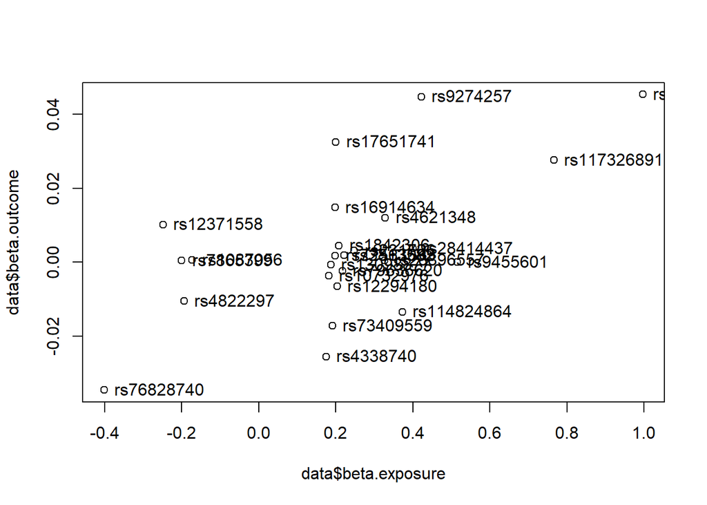

```r
plot(data$beta.exposure,data$beta.outcome)
text(data$beta.exposure,
     data$beta.outcome,
     labels = data$SNP,
     pos = 4)
```

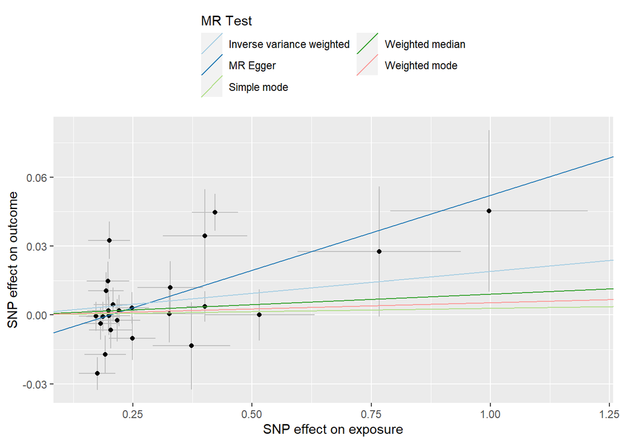

```r
#scatter plot
p1 <- mr_scatter_plot(res, data)
p1[[1]]
```

```r
#Heterogeneity testing
mr_heterogeneity<- mr_heterogeneity(data); mr_heterogeneity
```

```
##   id.exposure id.outcome outcome exposure                    method        Q
## 1      m3uO9x     DQN8hD outcome exposure                  MR Egger 62.24479
## 2      m3uO9x     DQN8hD outcome exposure Inverse variance weighted 70.41025
##   Q_df       Q_pval
## 1   23 1.798162e-05
## 2   24 1.894690e-06
```

```r
#pleiotropy testing
mr_pleiotropy_test<- mr_pleiotropy_test(data); mr_pleiotropy_test
```

```
##   id.exposure id.outcome outcome exposure egger_intercept          se
## 1      m3uO9x     DQN8hD outcome exposure     -0.01312795 0.007557778
##         pval
## 1 0.09576112
```

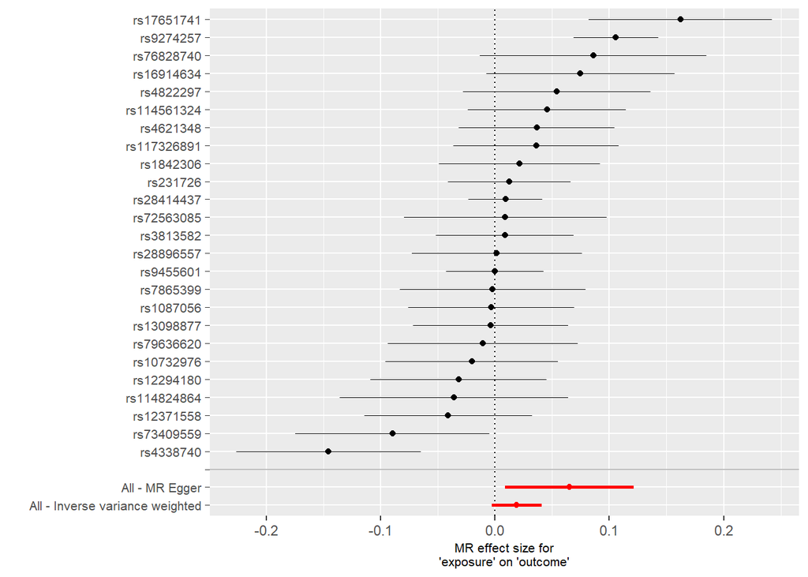

```r
#plot of single SNP MR:
res_single <- mr_singlesnp(data); p2 <- mr_forest_plot(res_single); p2[[1]]
```

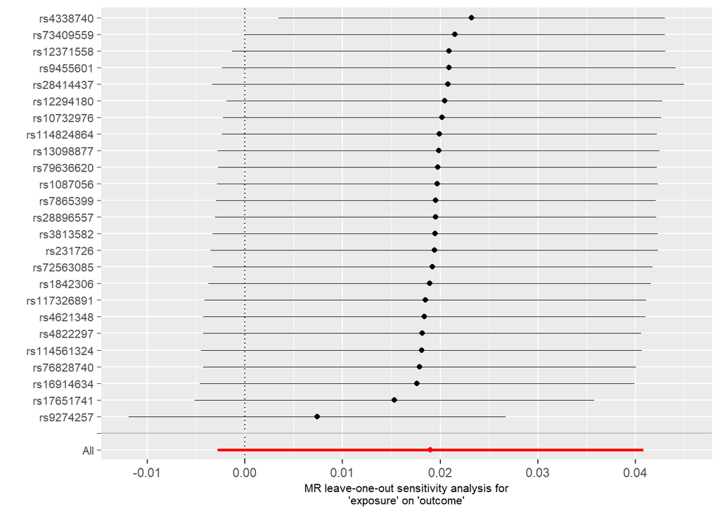

```r
#plot of LOO:
res_loo <- mr_leaveoneout(data); p3 <- mr_leaveoneout_plot(res_loo); p3[[1]]
```

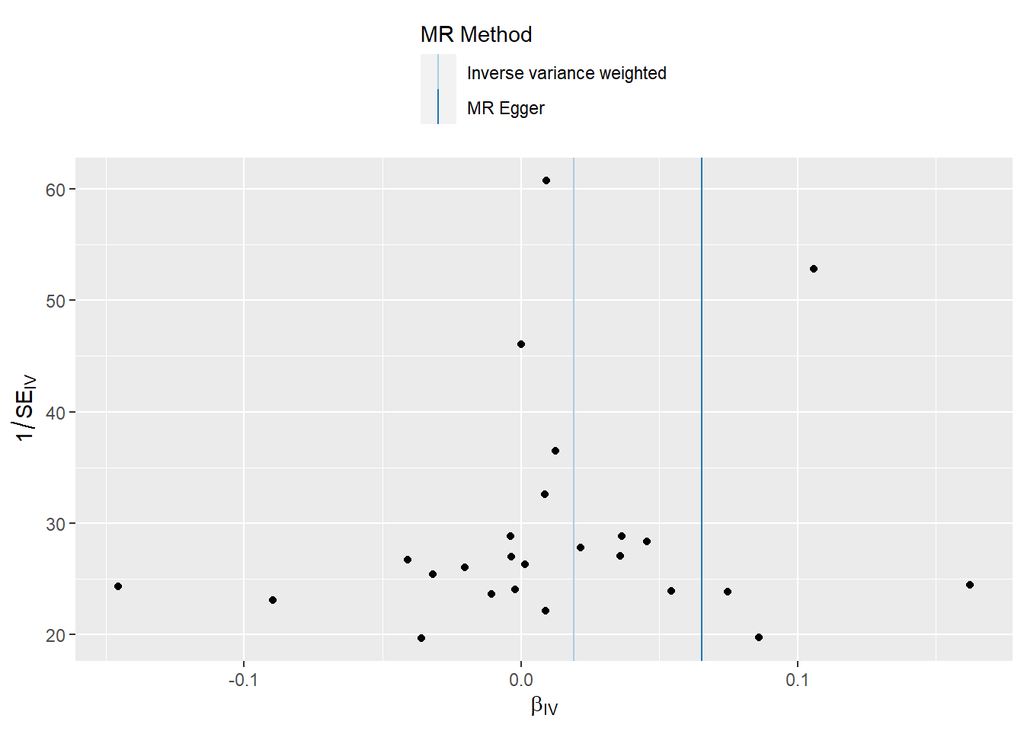

```r
#Funnel plot
p4 <- mr_funnel_plot(res_single); p4[[1]]
```

### Testing Outlier with PRESSO test

```
## $`Main MR results`
##        Exposure       MR Analysis Causal Estimate          Sd   T-stat
## 1 beta.exposure               Raw     0.018997587 0.011130321 1.706832
## 2 beta.exposure Outlier-corrected     0.007311073 0.006674337 1.095401
##     P-value
## 1 0.1007613
## 2 0.2857456
##
## $`MR-PRESSO results`
## $`MR-PRESSO results`$`Global Test`
## $`MR-PRESSO results`$`Global Test`$RSSobs
## [1] 79.2061
##
## $`MR-PRESSO results`$`Global Test`$Pvalue
## [1] "<0.001"
##
##
## $`MR-PRESSO results`$`Outlier Test`
##          RSSobs Pvalue
## 1  5.431799e-05      1
## 2  1.603200e-05      1
## 3  7.444958e-04      1
## 4  4.339455e-04      1
## 5  1.810411e-04      1
## 6  1.135760e-04      1
## 7  2.368345e-04      1
## 8  1.949326e-05      1
## 9  1.279222e-04      1
## 10 8.665048e-04 <0.025
## 11 3.082925e-07      1
## 12 2.914853e-06      1
## 13 2.146959e-05      1
## 14 3.443934e-05      1
## 15 5.828032e-06      1
## 16 8.740802e-04  0.025
## 17 3.557999e-05      1
## 18 4.886994e-05      1
## 19 4.081558e-06      1
## 20 4.547381e-04    0.2
## 21 7.469633e-04      1
## 22 1.849826e-05      1
## 23 4.333935e-05      1
## 24 1.728062e-03 <0.025
## 25 1.157323e-04      1
##
## $`MR-PRESSO results`$`Distortion Test`
## $`MR-PRESSO results`$`Distortion Test`$`Outliers Indices`
## [1] 10 16 24
##
## $`MR-PRESSO results`$`Distortion Test`$`Distortion Coefficient`
## beta.exposure
##      159.8468
##
## $`MR-PRESSO results`$`Distortion Test`$Pvalue
## [1] "<0.001"
```

```
##   id.exposure id.outcome outcome exposure                    method nsnp
## 1      m3uO9x     DQN8hD outcome exposure                  MR Egger   25
## 2      m3uO9x     DQN8hD outcome exposure           Weighted median   25
## 3      m3uO9x     DQN8hD outcome exposure Inverse variance weighted   25
## 4      m3uO9x     DQN8hD outcome exposure               Simple mode   25
## 5      m3uO9x     DQN8hD outcome exposure             Weighted mode   25
##             b         se       pval
## 1 0.065288410 0.02871384 0.03263161
## 2 0.009136803 0.01027267 0.37377284
## 3 0.018997587 0.01113032 0.08785329
## 4 0.002902478 0.01542967 0.85237175
## 5 0.005399537 0.01200487 0.65690612
```

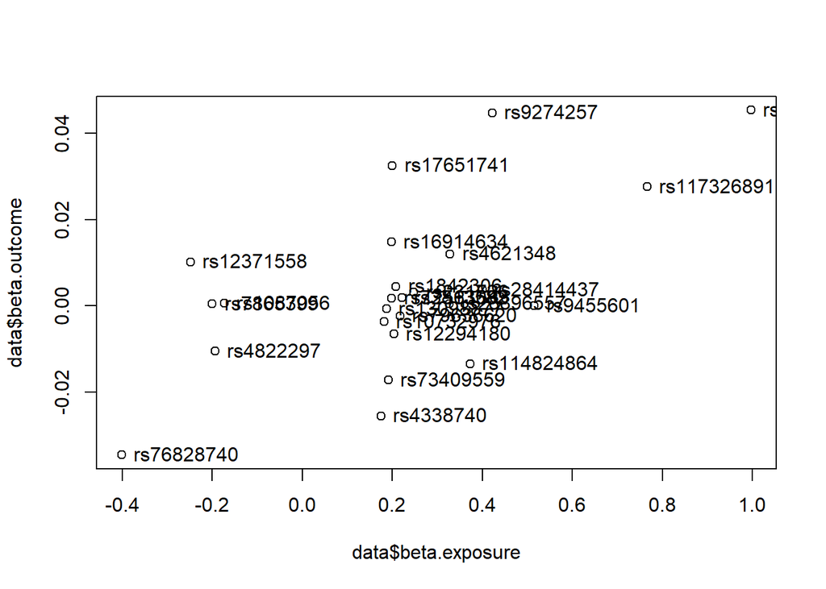

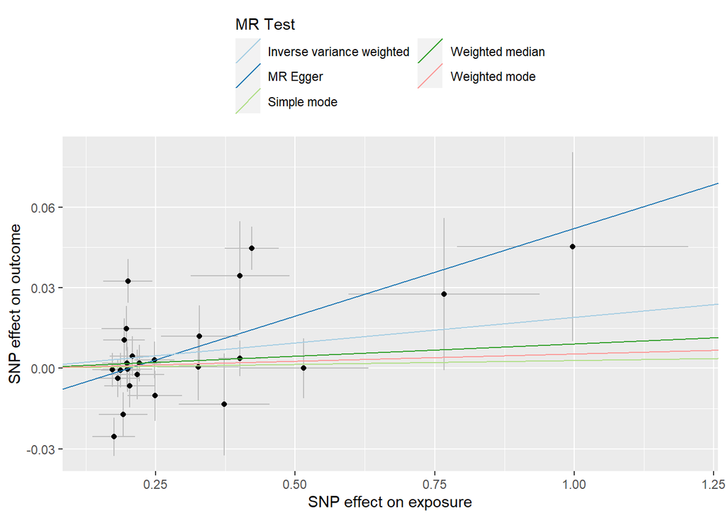

```
##   id.exposure id.outcome outcome exposure                    method        Q
## 1      m3uO9x     DQN8hD outcome exposure                  MR Egger 62.24479
## 2      m3uO9x     DQN8hD outcome exposure Inverse variance weighted 70.41025
##   Q_df       Q_pval
## 1   23 1.798162e-05
## 2   24 1.894690e-06
```

```
##   id.exposure id.outcome outcome exposure egger_intercept          se
## 1      m3uO9x     DQN8hD outcome exposure     -0.01312795 0.007557778
##         pval
## 1 0.09576112
```

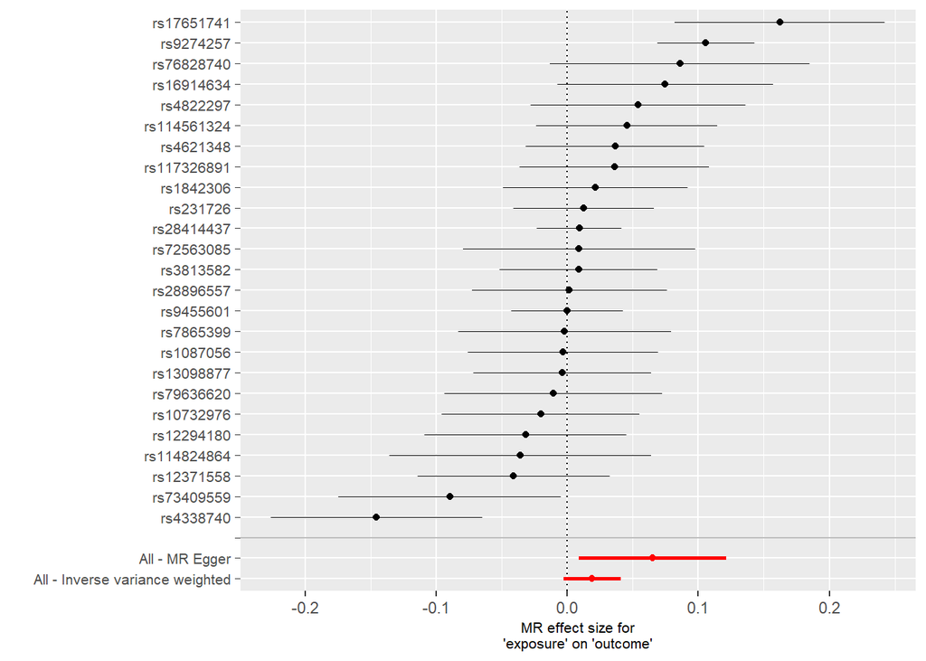

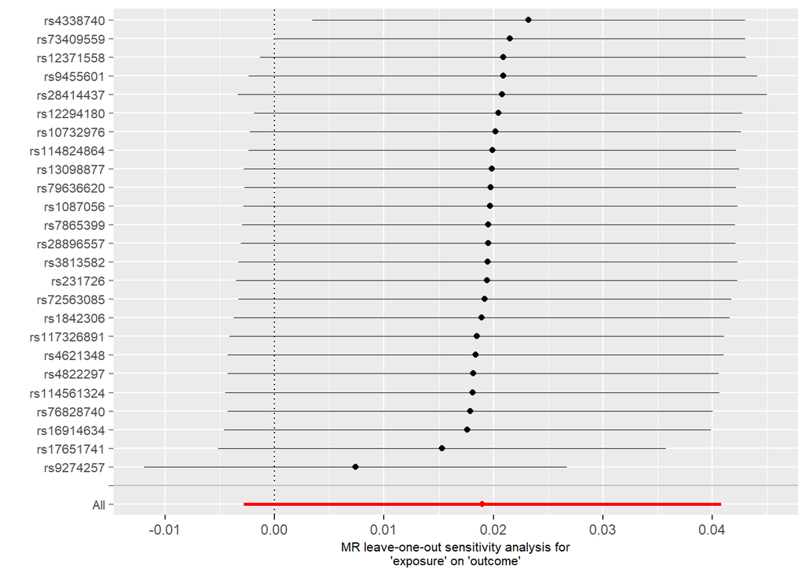

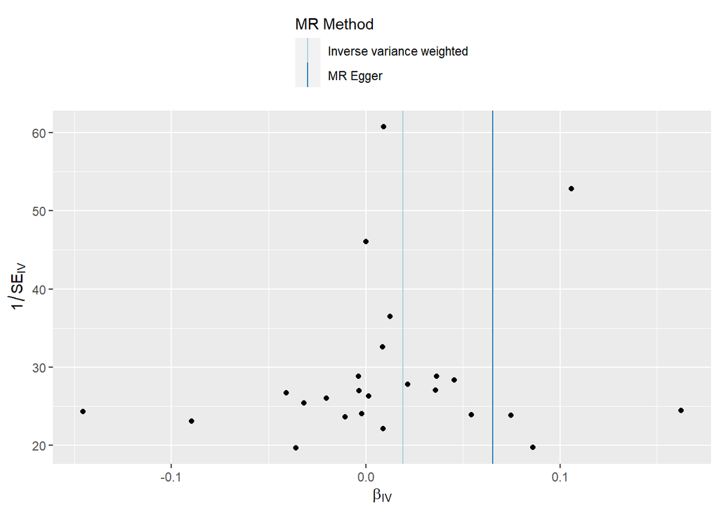

### Studentized residuals:

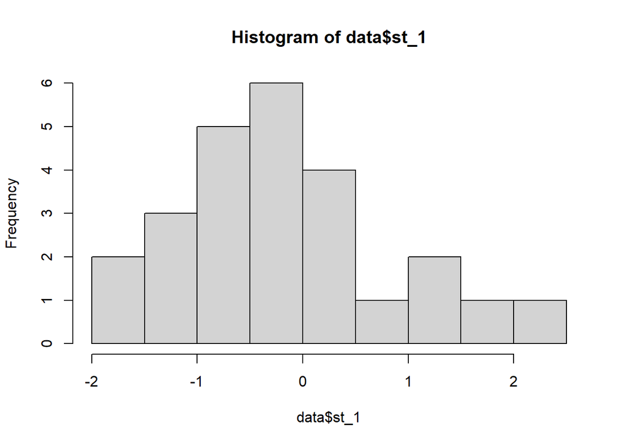

```r
reg_1<-lm(data$beta.outcome~data$beta.exposure-1)
data$st_1<-rstandard(reg_1)

#Histogram plot
hist(data$st_1)
```

### Radial test

```
##
## Radial IVW
##
##                    Estimate  Std.Error  t value    Pr(>|t|)
## Effect (Mod.2nd) 0.01901729 0.01114274 1.706698 0.087878249
## Iterative        0.01901729 0.01114274 1.706698 0.087878249
## Exact (FE)       0.02097768 0.00655203 3.201707 0.001366159
## Exact (RE)       0.01962752 0.01286620 1.525510 0.140203136
##
##
## Residual standard error: 1.703 on 24 degrees of freedom
##
## F-statistic: 2.91 on 1 and 24 DF, p-value: 0.101
## Q-Statistic for heterogeneity: 69.61735 on 24 DF , p-value: 2.498265e-06
##
##  Outliers detected
## Number of iterations = 2
```

```
##          SNP Q_statistic      p.value
## 1 rs17651741    12.11457 5.002940e-04
## 2  rs4338740    15.86951 6.786339e-05
## 3  rs9274257    20.72924 5.290192e-06
```

### Cook’s distance

In statistics, Cook’s distance or Cook’s D is a commonly used estimate of the influence of a data point when performing a least-squares regression analysis.[1] In a practical ordinary least squares analysis, Cook’s distance can be used in several ways:

1- To indicate influential data points that are particularly worth checking for validity.

2- To indicate regions of the design space where it would be good to be able to obtain more data points.

**It is named after the American statistician R. Dennis Cook, who introduced the concept in 1977.**

[Refernce](https://en.wikipedia.org/wiki/Cook%27s_distance)

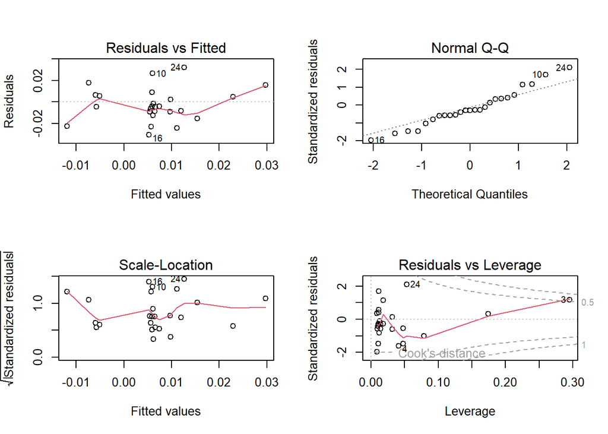

```r
par(mfrow = c(2, 2))
model <- lm(data$beta.outcome~data$beta.exposure-1)
plot(model)
```

```r
par(mfrow = c(1, 1))

cooksD <- cooks.distance(model)
influential <- cooksD[(cooksD > (3 * mean(cooksD, na.rm = TRUE)))]
influential
```

```
##         3        24
## 0.5869178 0.2487492
```

### Run After deleting new outlier: Final Results:

```r
data <- data[(data$SNP!="rs17651741" & data$SNP!="rs4338740" &  data$SNP!="rs9274257"
              & data$SNP!="rs79636620" &data$SNP!="rs73409559"
              & data$SNP!="rs12371558" & data$SNP!="rs114824864"
              & data$SNP!="rs12294180" & data$SNP!="rs10732976"),]

res<-mr(data)

res
```

```
##   id.exposure id.outcome outcome exposure                    method nsnp
## 1      m3uO9x     DQN8hD outcome exposure                  MR Egger   16
## 2      m3uO9x     DQN8hD outcome exposure           Weighted median   16
## 3      m3uO9x     DQN8hD outcome exposure Inverse variance weighted   16
## 4      m3uO9x     DQN8hD outcome exposure               Simple mode   16
## 5      m3uO9x     DQN8hD outcome exposure             Weighted mode   16
##             b          se       pval
## 1 0.021353684 0.020203463 0.30844033
## 2 0.009198712 0.010697285 0.38983813
## 3 0.017017499 0.007860121 0.03038439
## 4 0.004328740 0.015344174 0.78171456
## 5 0.006117096 0.012059544 0.61936129
```

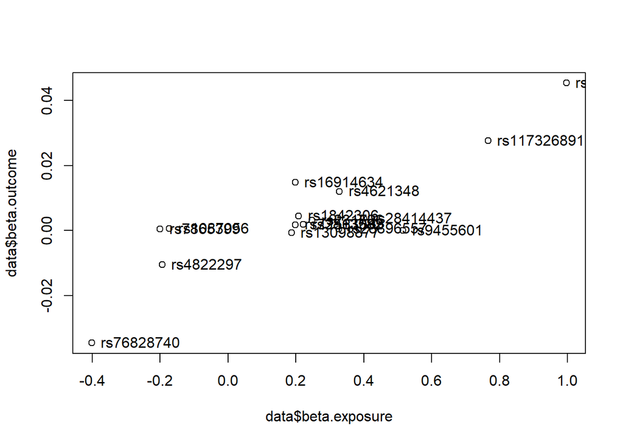

```r
plot(data$beta.exposure,data$beta.outcome)
text(data$beta.exposure,
     data$beta.outcome,
     labels = data$SNP,
     pos = 4)
```

```r
#Heterogeneity testing
mr_heterogeneity<- mr_heterogeneity(data); mr_heterogeneity
```

```
##   id.exposure id.outcome outcome exposure                    method        Q
## 1      m3uO9x     DQN8hD outcome exposure                  MR Egger 7.746462
## 2      m3uO9x     DQN8hD outcome exposure Inverse variance weighted 7.800742
##   Q_df    Q_pval
## 1   14 0.9021120
## 2   15 0.9315224
```

```r
#pleiotropy testing
mr_pleiotropy_test<- mr_pleiotropy_test(data); mr_pleiotropy_test
```

```
##   id.exposure id.outcome outcome exposure egger_intercept          se      pval
## 1      m3uO9x     DQN8hD outcome exposure    -0.001290484 0.005539017 0.8191482
```

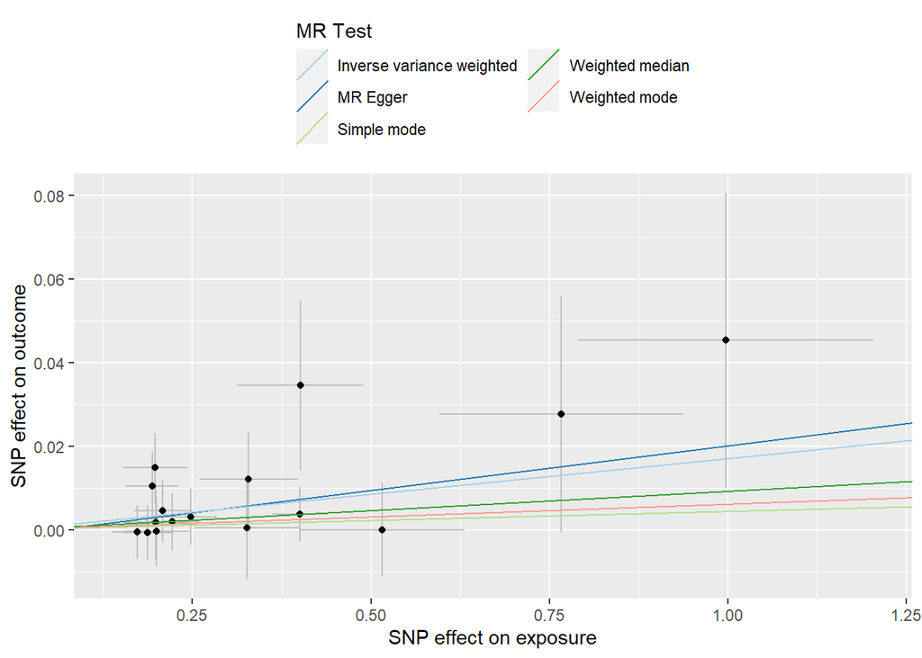

```r
#scatter plot
p1 <- mr_scatter_plot(res, data); p1[[1]]
```

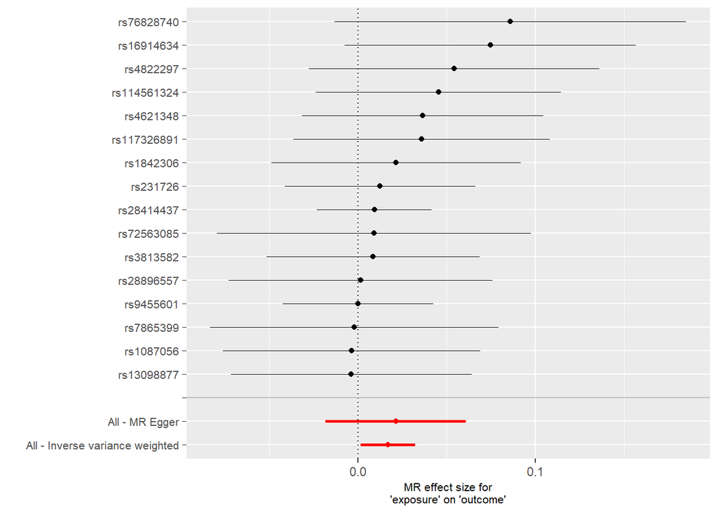

```r
#plot of single SNP MR:
res_single <- mr_singlesnp(data); p2 <- mr_forest_plot(res_single); p2[[1]]
```

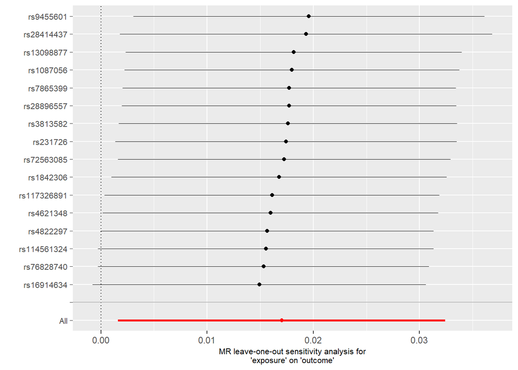

```r
#plot of LOO:
res_loo <- mr_leaveoneout(data); p3 <- mr_leaveoneout_plot(res_loo); p3[[1]]
```

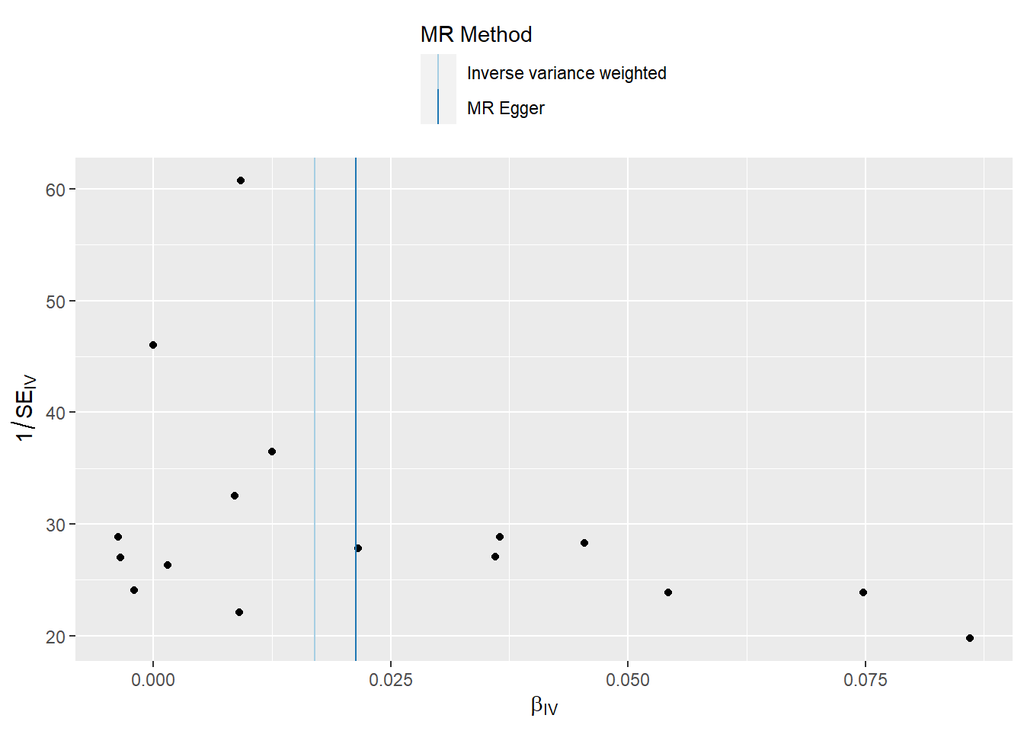

```r
#Funnel plot
p4 <- mr_funnel_plot(res_single); p4[[1]]
```

### Sensitivity analyses with MendelianRandomization Package

```
##
## Inverse-variance weighted method
## (variants uncorrelated, random-effect model)
##
## Number of Variants : 16
##
## ------------------------------------------------------------------
##  Method Estimate Std Error 95% CI       p-value
##     IVW    0.017     0.008 0.002, 0.032   0.030
## ------------------------------------------------------------------
## Residual standard error =  0.721
## Residual standard error is set to 1 in calculation of confidence interval when its estimate is less than 1.
## Heterogeneity test statistic (Cochran's Q) = 7.8007 on 15 degrees of freedom, (p-value = 0.9315). I^2 = 0.0%.
## F statistic = 30.2.
```

```
##                     Method Estimate Std Error 95% CI        P-value
##              Simple median    0.011     0.011  -0.010 0.032   0.317
##            Weighted median    0.009     0.011  -0.012 0.030   0.390
##  Penalized weighted median    0.009     0.011  -0.012 0.030   0.390
##
##                        IVW    0.017     0.008   0.002 0.032   0.030
##              Penalized IVW    0.017     0.008   0.002 0.032   0.030
##                 Robust IVW    0.015     0.010  -0.005 0.035   0.132
##       Penalized robust IVW    0.015     0.010  -0.005 0.035   0.132
##
##                   MR-Egger    0.021     0.020  -0.018 0.061   0.291
##                (intercept)   -0.001     0.006  -0.012 0.010   0.816
##         Penalized MR-Egger    0.021     0.020  -0.018 0.061   0.291
##                (intercept)   -0.001     0.006  -0.012 0.010   0.816
##            Robust MR-Egger    0.023     0.031  -0.038 0.084   0.458
##                (intercept)   -0.002     0.009  -0.020 0.015   0.789
##  Penalized robust MR-Egger    0.023     0.031  -0.038 0.084   0.458
##                (intercept)   -0.002     0.009  -0.020 0.015   0.789
```

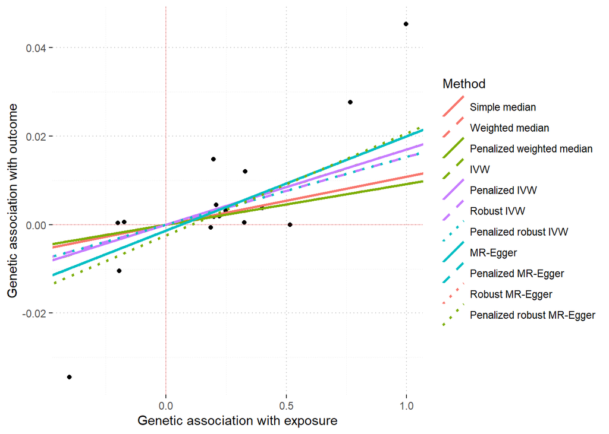

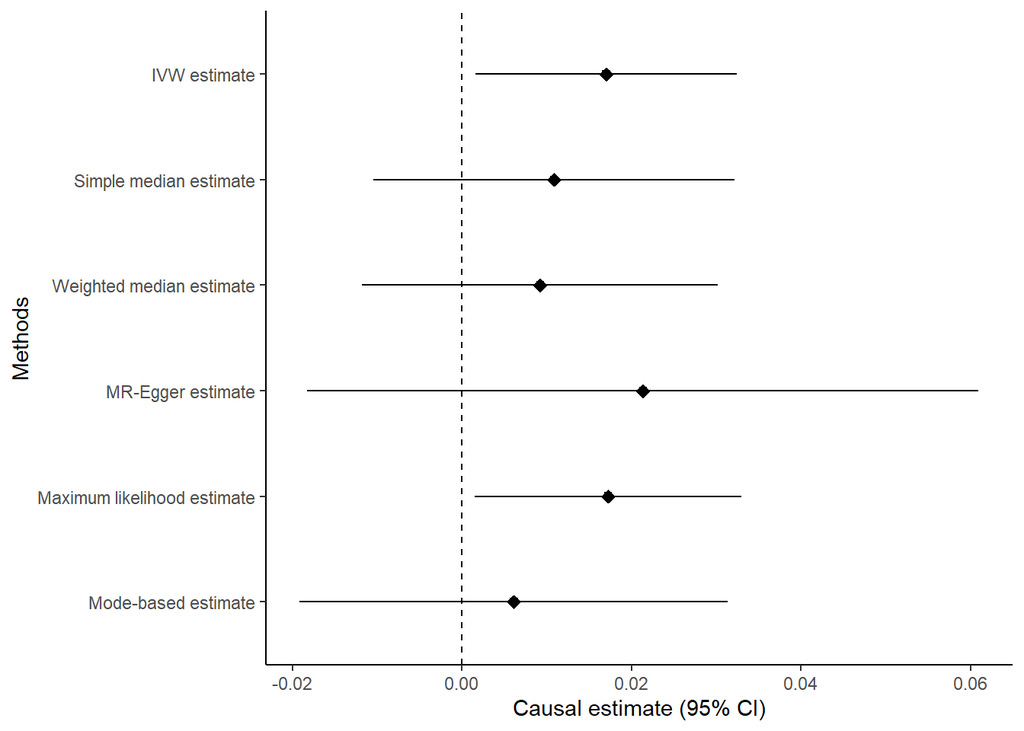

| id.exposure | id.outcome | exposure | outcome | snp_r2.exposure | snp_r2.outcome | correct_causal_direction | steiger_pval |
| --- | --- | --- | --- | --- | --- | --- | --- |
| m3uO9x | DQN8hD | exposure | outcome | 0.00036 | 2.73e-05 | TRUE | 0 |

```
## $r2_exp
## [1] 0
##
## $r2_out
## [1] 0.25
##
## $r2_exp_adj
## [1] 0
##
## $r2_out_adj
## [1] 0.25
##
## $correct_causal_direction
## [1] FALSE
##
## $steiger_test
## [1] 0
##
## $correct_causal_direction_adj
## [1] FALSE
##
## $steiger_test_adj
## [1] 0
##
## $vz
## [1] NaN
##
## $vz0
## [1] 0
##
## $vz1
## [1] NaN
##
## $sensitivity_ratio
## [1] NaN
##
## $sensitivity_plot
```

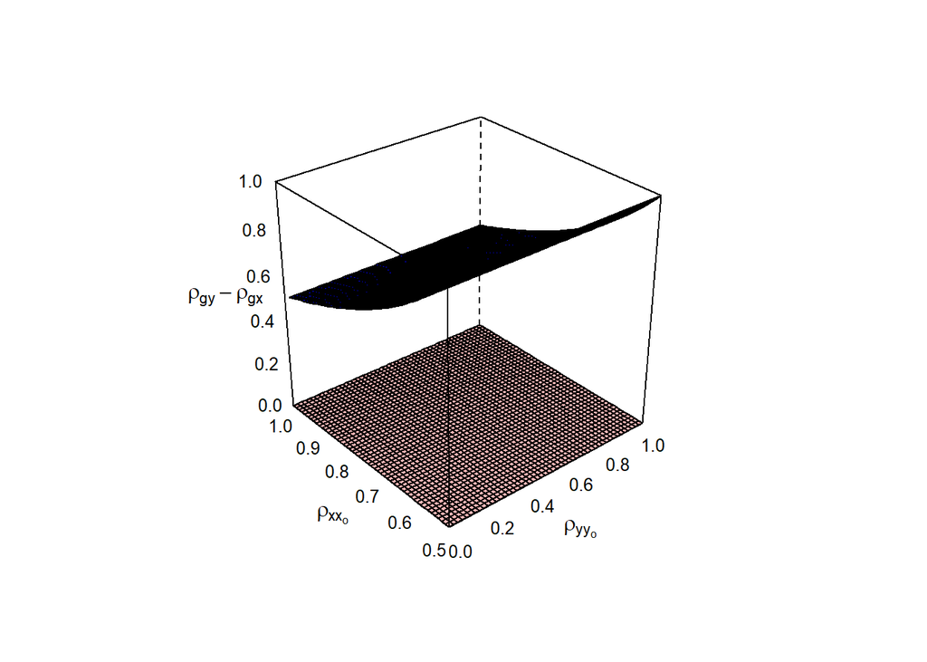

### Working with MRraps

```
## $beta.hat
## [1] 0.01734983
##
## $beta.se
## [1] 0.008294435
##
## $beta.p.value
## [1] 0.03646143
##
## $naive.se
## [1] 0.0081497
##
## $chi.sq.test
## [1] 7.724973
```

```
##   over.dispersion loss.function   beta.hat     beta.se
## 1           FALSE            l2 0.01734983 0.008294435
## 2           FALSE         huber 0.01730813 0.008509423
## 3           FALSE         tukey 0.01668880 0.008502398
## 4            TRUE            l2 0.01735043 0.008298819
## 5            TRUE         huber 0.01730812 0.008513589
## 6            TRUE         tukey 0.01669042 0.008506434
```

```
##
## MR-Lasso method
##
## Number of variants : 16
## Number of valid instruments : 16
## Tuning parameter : 0.3514503
## ------------------------------------------------------------------
##  Exposure Estimate Std Error 95% CI       p-value
##  exposure    0.017     0.008 0.002, 0.032   0.030
## ------------------------------------------------------------------
```

```
##
## Constrained maximum likelihood method (MRcML)
## Number of Variants:  16
## Results for:  cML-MA-BIC
## ------------------------------------------------------------------
##      Method Estimate    SE Pvalue        95% CI
##  cML-MA-BIC    0.017 0.008  0.031 [0.002,0.033]
## ------------------------------------------------------------------
```

```
##
## Debiased inverse-variance weighted method
## (Over.dispersion:TRUE)
##
## Number of Variants : 16
## ------------------------------------------------------------------
##  Method Estimate Std Error 95% CI       p-value Condition
##    dIVW    0.018     0.008 0.002, 0.034   0.031   116.631
## ------------------------------------------------------------------
```

```
##
## Mode-based method of Hartwig et al
## (weighted, delta standard errors [not assuming NOME], bandwidth factor = 1)
##
## Number of Variants : 16
## ------------------------------------------------------------------
##  Method Estimate Std Error  95% CI       p-value
##     MBE    0.006     0.013 -0.020, 0.032   0.646
## ------------------------------------------------------------------
```

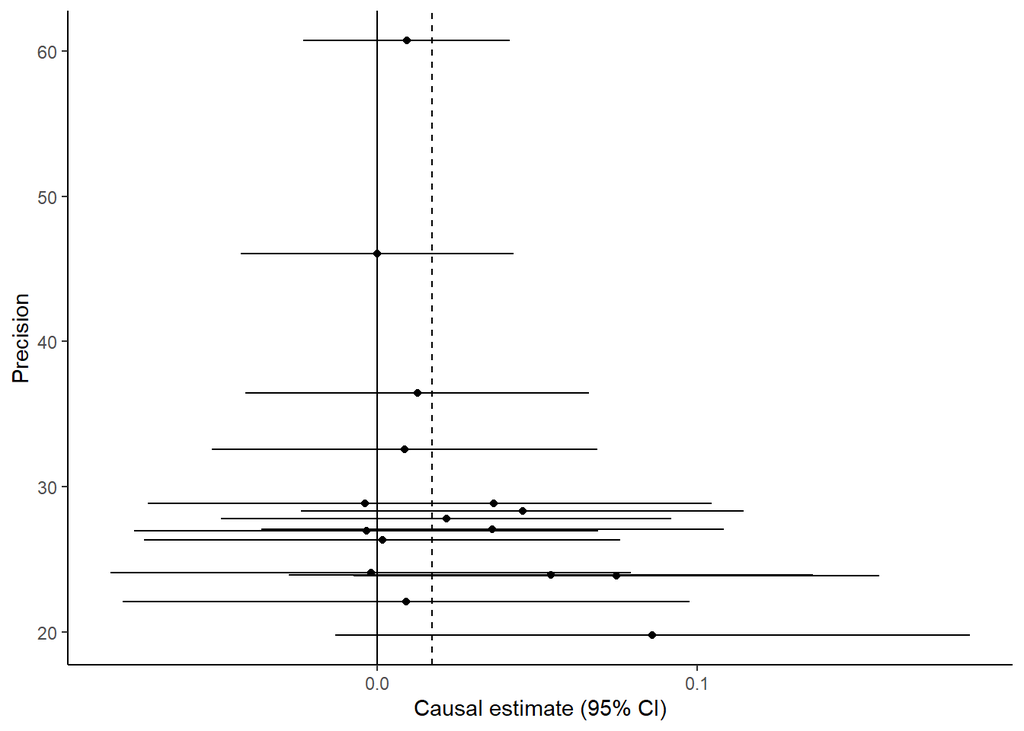

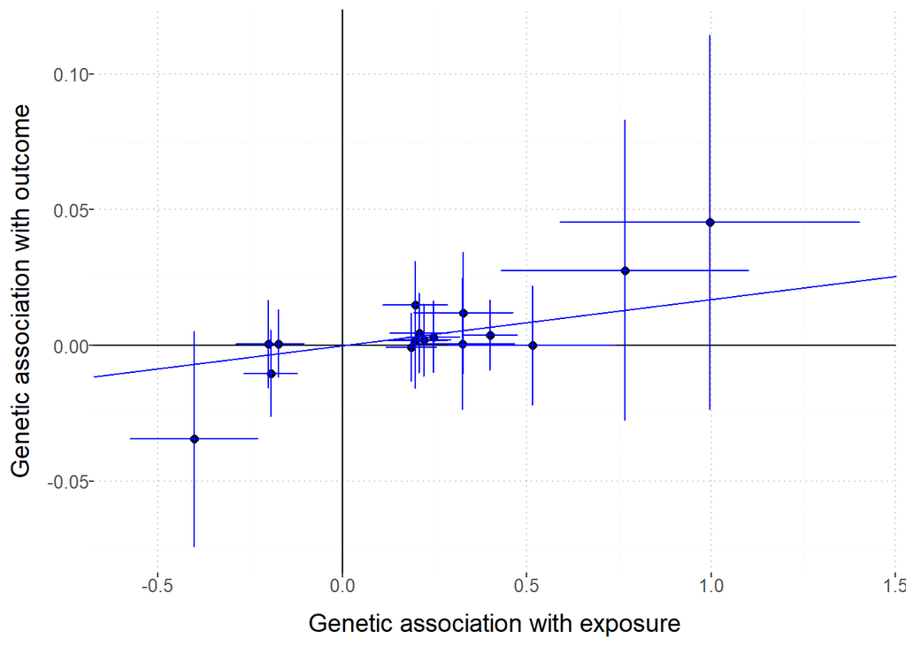

## [T2D on Graves’ disease (GD)]

### Introduction

- **Title:** Investigating the causality between **T2D on GD**
  - Exposure:T2D, [DIAGRAM consortium](https://diagram-consortium.org/) | Reference paper: [Mahajan Paper 2022](https://www.nature.com/articles/s41588-022-01058-3) | GWAS ID:GCST90132184
  - **Sample size**:1,339,889 , **Number of cases**:180,834 , **Number of controls**: 1,159,055
  - Outcome: [NBC Human Database](https://humandbs.biosciencedbc.jp/en/hum0197-v3-220) | Reference paper: [Saori Sakaue Paper 2021](https://pubmed.ncbi.nlm.nih.gov/34594039/) | GWAS ID: GCST90018847
  - **Sample size**: 458,620 , **Number of cases**: 1,678 , **Number of controls**: 456,942
  - Ancestry: **European**

### Data Preparation

1- **Number of total SNPs in exposure:** 10,454,875 SNPs

2- **Number of SNPs exposure with p-value <** $5\times 10^-8$ = 17,450 SNPs

3- **Number of SNPs exposure after clumping** = 187 SNPs

4- **Number of total SNPs in outcome**: 18,904,735 SNPs

5- **Number of common variants between exposure and outcome**: 170 SNPs

6- **Number of SNPs after harmonization (action=2)** = 165 SNPs

8- **Number of SNPs after removing HLA region with exploring in [HLA Genes, Nomenclature](https://hla.alleles.org/genes/index.html)** = 165 SNP

9- **Number of SNPs after removing those that have MAF < 0.01** = 165 SNPs

### Checking weakness of the instruments

```r
data <- fread("dataAftScan_T2D_GD.txt")
data$F<-(data$beta.exposure/data$se.exposure)^2
summary(data$F)
```

```
##    Min. 1st Qu.  Median    Mean 3rd Qu.    Max.
##   29.75   35.12   47.69   75.24   68.49 1415.77
```

How many SNPs have been eliminated with checking the weakness: 0 SNP

### RUN an initial MR:

```r
res<-mr(data)
res
```

```
##   id.exposure id.outcome outcome exposure                    method nsnp
## 1      nMQuaa     WAeJus outcome exposure                  MR Egger  163
## 2      nMQuaa     WAeJus outcome exposure           Weighted median  163
## 3      nMQuaa     WAeJus outcome exposure Inverse variance weighted  163
## 4      nMQuaa     WAeJus outcome exposure               Simple mode  163
## 5      nMQuaa     WAeJus outcome exposure             Weighted mode  163
##             b         se       pval
## 1  0.12276715 0.13784561 0.37446555
## 2 -0.01189484 0.08627093 0.89033706
## 3  0.12682621 0.05867995 0.03067055
## 4  0.12024736 0.21696751 0.58019373
## 5 -0.05824805 0.12422362 0.63977382
```

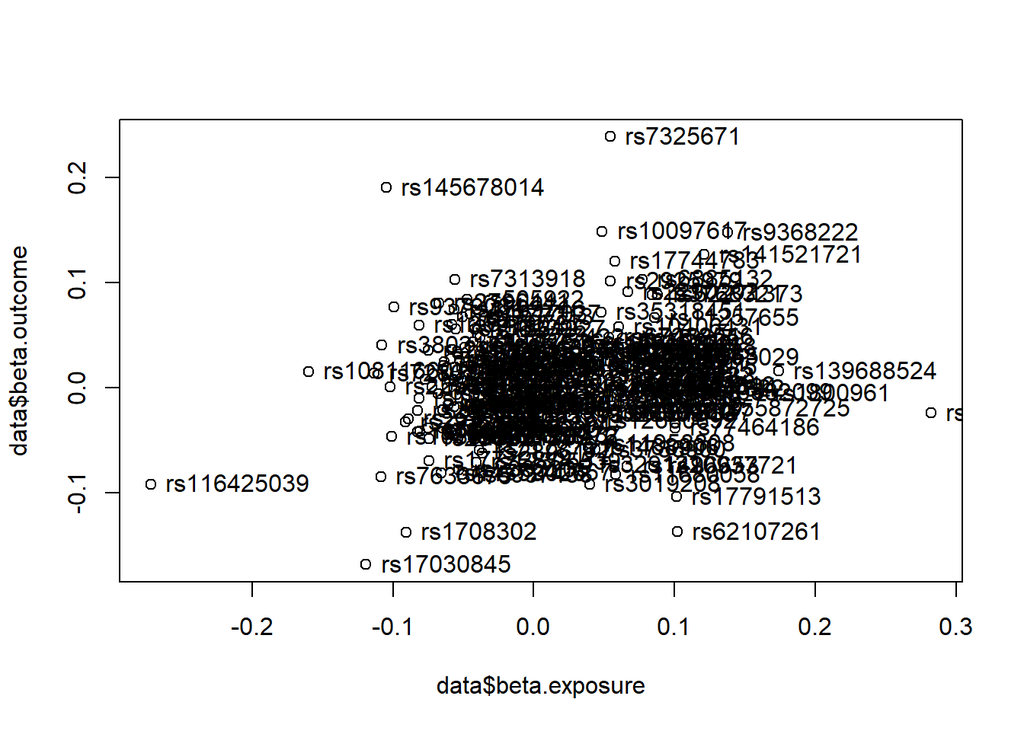

```r
plot(data$beta.exposure,data$beta.outcome)
text(data$beta.exposure,
     data$beta.outcome,
     labels = data$SNP,
     pos = 4)
```

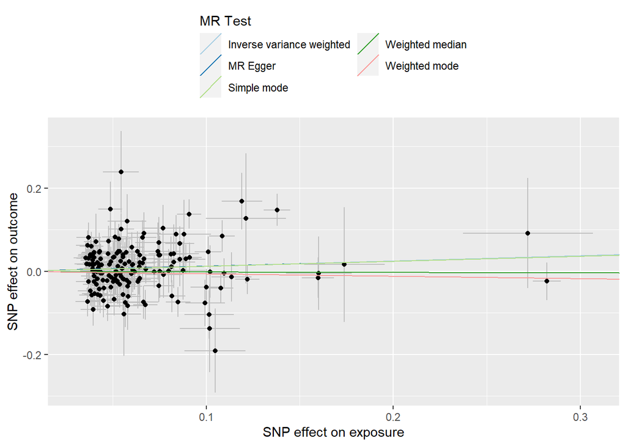

```r
#scatter plot
p1 <- mr_scatter_plot(res, data)
p1[[1]]
```

```r
#Heterogeneity testing
mr_heterogeneity<- mr_heterogeneity(data); mr_heterogeneity
```

```
##   id.exposure id.outcome outcome exposure                    method        Q
## 1      nMQuaa     WAeJus outcome exposure                  MR Egger 221.0518
## 2      nMQuaa     WAeJus outcome exposure Inverse variance weighted 221.0533
##   Q_df      Q_pval
## 1  161 0.001187660
## 2  162 0.001413119
```

```r
#pleiotropy testing
mr_pleiotropy_test<- mr_pleiotropy_test(data); mr_pleiotropy_test
```

```
##   id.exposure id.outcome outcome exposure egger_intercept          se      pval
## 1      nMQuaa     WAeJus outcome exposure    0.0002939165 0.009025637 0.9740621
```

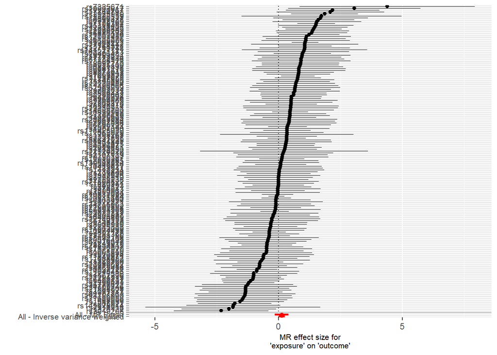

```r
#plot of single SNP MR:
res_single <- mr_singlesnp(data); p2 <- mr_forest_plot(res_single); p2[[1]]
```

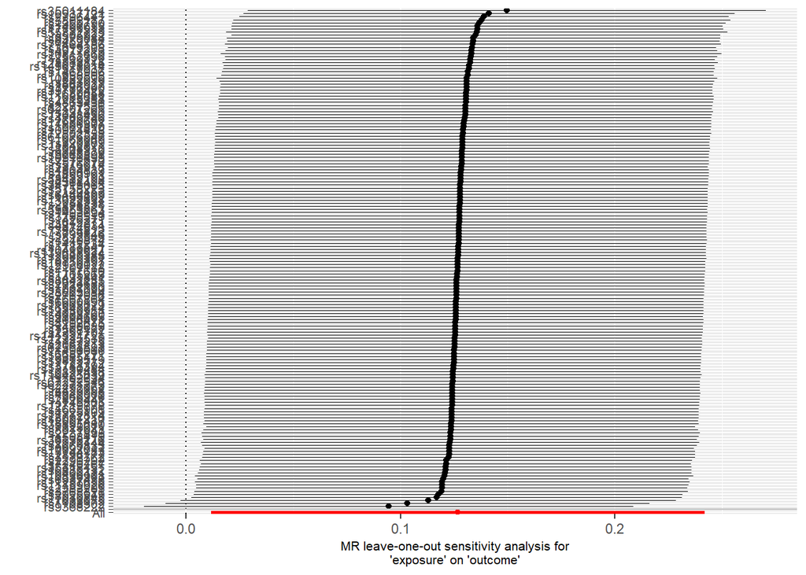

```r
#plot of LOO:
res_loo <- mr_leaveoneout(data); p3 <- mr_leaveoneout_plot(res_loo); p3[[1]]
```

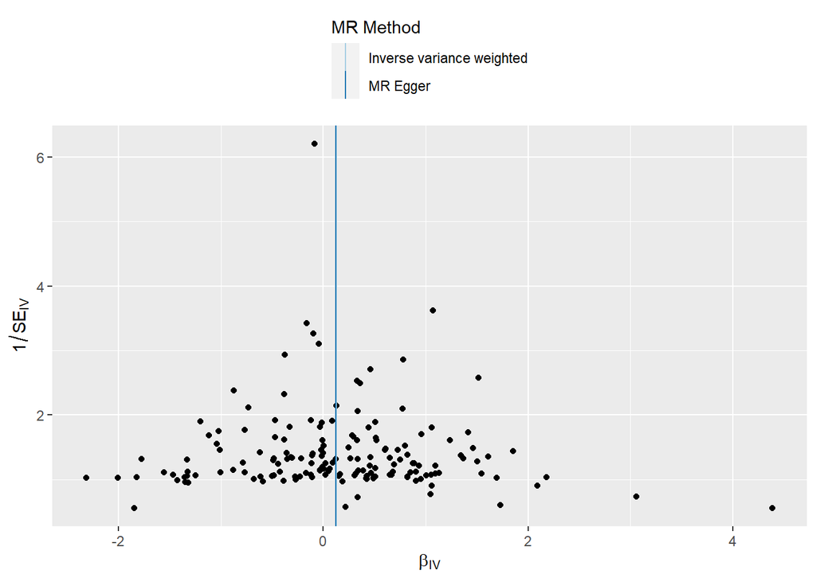

```r
#Funnel plot
p4 <- mr_funnel_plot(res_single); p4[[1]]
```

### Testing Outlier with PRESSO test

```
## $`Main MR results`
##        Exposure       MR Analysis Causal Estimate         Sd   T-stat
## 1 beta.exposure               Raw      0.12682621 0.05867995 2.161321
## 2 beta.exposure Outlier-corrected      0.06955232 0.05694722 1.221347
##      P-value
## 1 0.03213897
## 2 0.22375128
##
## $`MR-PRESSO results`
## $`MR-PRESSO results`$`Global Test`
## $`MR-PRESSO results`$`Global Test`$RSSobs
## [1] 224.9441
##
## $`MR-PRESSO results`$`Global Test`$Pvalue
## [1] "<0.001"
```

[output cut: 178 more lines]

```
##   id.exposure id.outcome outcome exposure                    method nsnp
## 1      nMQuaa     WAeJus outcome exposure                  MR Egger  143
## 2      nMQuaa     WAeJus outcome exposure           Weighted median  143
## 3      nMQuaa     WAeJus outcome exposure Inverse variance weighted  143
## 4      nMQuaa     WAeJus outcome exposure               Simple mode  143
## 5      nMQuaa     WAeJus outcome exposure             Weighted mode  143
##           b         se       pval
## 1 0.1909742 0.23806056 0.42378242
## 2 0.1619115 0.09742277 0.09652330
## 3 0.1119229 0.06505319 0.08534469
## 4 0.2864514 0.24572685 0.24567747
## 5 0.3222973 0.22603017 0.15609072
```

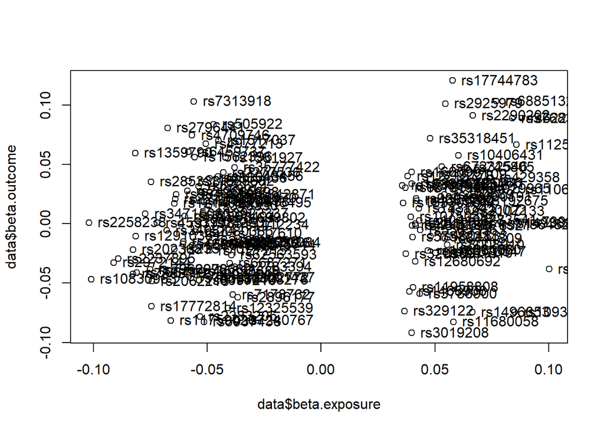

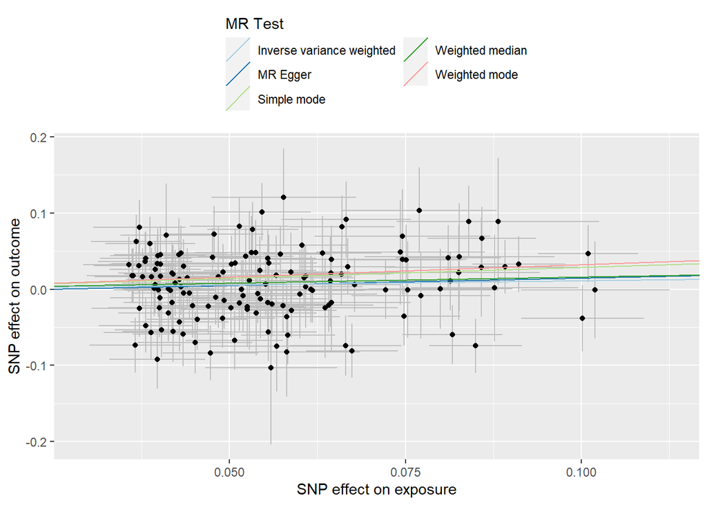

```
##   id.exposure id.outcome outcome exposure                    method        Q
## 1      nMQuaa     WAeJus outcome exposure                  MR Egger 158.3569
## 2      nMQuaa     WAeJus outcome exposure Inverse variance weighted 158.4908
##   Q_df    Q_pval
## 1  141 0.1507308
## 2  142 0.1629892
```

```
##   id.exposure id.outcome outcome exposure egger_intercept         se      pval
## 1      nMQuaa     WAeJus outcome exposure    -0.004576065 0.01325284 0.7303914
```

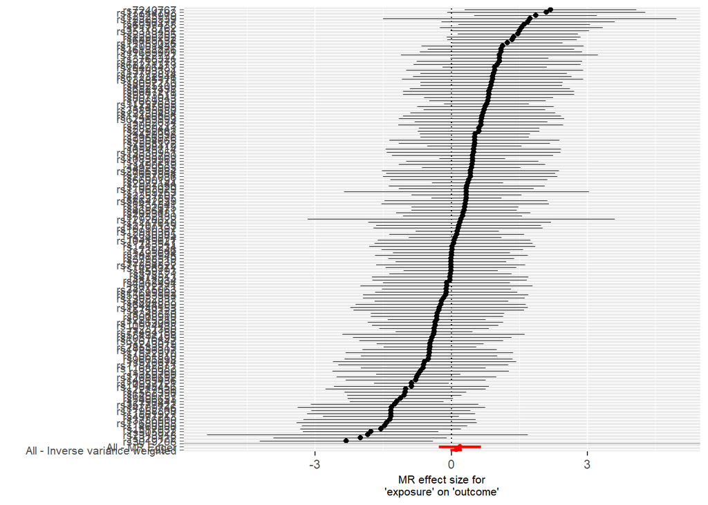

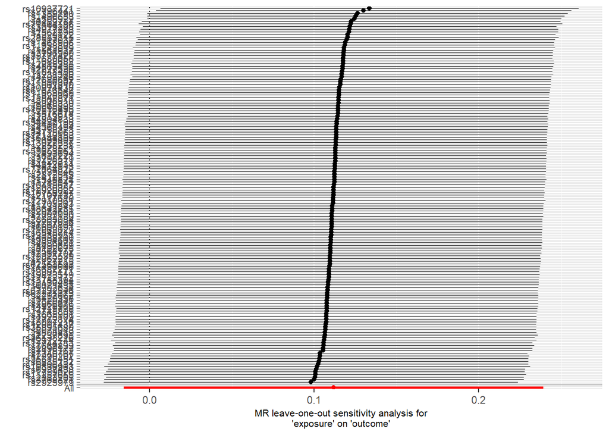

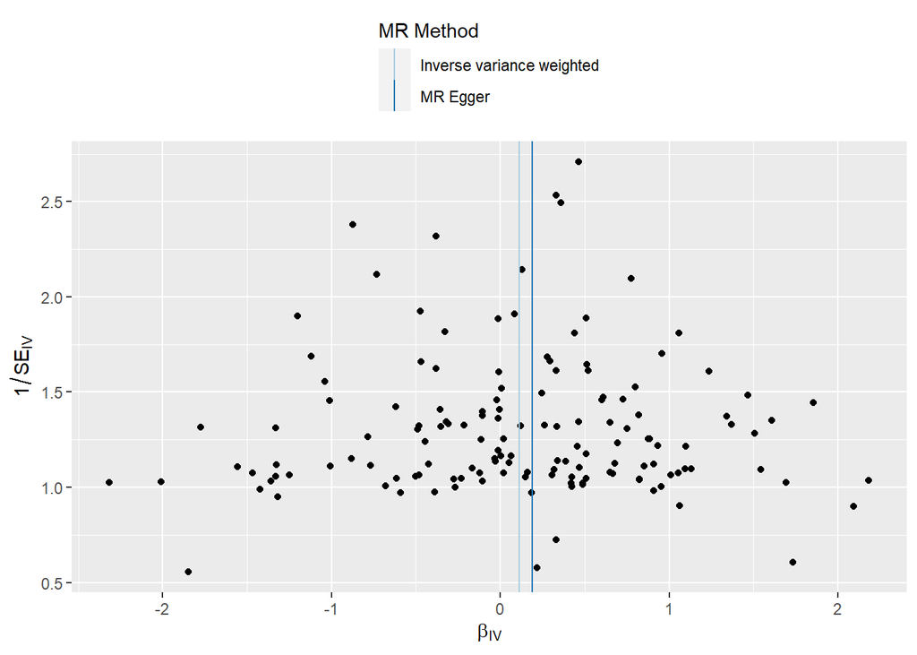